# Reading Data Into SAS

Data with Prespecified Column Spacing (No Within-Subject Delimiter)

## Dataset with Prespecified Spacing

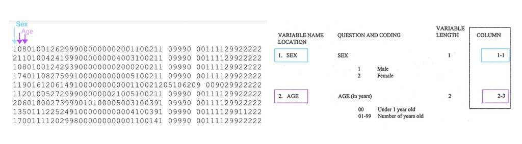

Here, you are given a text file with a continuous stream of numbers with no variable label and no delimiter (e.g. tab, comma, etc). Each row corresponds to individual observation and any white space implies missing data.

If you are given a dataset similar to the text file above, you should be given a coding sheet with data descriptors such as variable names and their designated column numbers.

Here, the sheet tells you that `sex` is in column 1 (where 1 = “Male”, 2 = “Female”) while `age` is in columns 2-3.

## Step by Step Guide: Loading Sex, Age (Part I)

Below is the general structure to create a SAS data. I am choosing to call it ‘nhis_data’.

```
data nhis_data;
  {to be filled}
run;
```

The infile statement I created tells SAS the path where the data is located.

```
data nhis_data;
  infile "\\Client\H$\Documents\Regression_Analysis\nhis_data.txt";
  {to be filled}
run;
```

## Step by Step Guide: Loading Sex, Age (Part II)

Next, I am telling SAS to create a `sex` variable. Here, I am specifying to treat column 1 as the entries for the `sex` variable.

```
data nhis_data;
  infile "\\Client\H$\Documents\Regression_Analysis\nhis_data.txt";
  input sex 1 {to be filled};
run;
```

Finally, according to the coding scheme presented earlier, `age` is located in columns 2-3. The finalized code below tells SAS to create a `nhis_data` dataset, find the relevant file using the infile statement, and create both `sex` and `age` variables that are located in columns 1 and 2-3, respectively.

```
data nhis_data;
  infile "\\Client\H$\Documents\Regression_Analysis\nhis_data.txt";
  input sex 1 age 2-3;
run;
```

## Verification

We may use `proc print` to verify our work:

```
proc print data=nhis_data (obs=5);
run;
```

Output:

[figure not shown]

## Mutating the Data

Suppose you want to the accomplish the following task: change the 1-2 coding of gender to their categorical names (F for female, M for male); and create a categorical age variable where individuals are labeled “AgeCat1” when below 30, “AgeCat2” when 30 to below 60, and “AgeCat3” when 60 or older.

Here’s one way to accomplish both:

```
data nhis_data_v2;
    infile "\\Client\H$\Documents\Regression_Analysis\ReadingSAS\nhis_data.txt";
    input sex 1 age 2-3;

    if sex = 1 then sex_v2 = "M";
    else sex_v2 = "F";

    if 0 <= age < 30 then age_v2 = "AgeCat1";
    else if 30 <= age < 60 then age_v2 = "AgeCat2";
    else age_v2 = "AgeCat3";
run;
```

## Verification

We may use `proc print` to verify our work:

```
proc print data=nhis_data_v2 (obs=5);
run;
```

Output:

[figure not shown]